# **What affects COVID Vaccination rates the most?**

### By Hafsa Karim and Matthee Sabulao

### Published May 16th, 2022

In December of 2019, the first cluster of Covid cases occurred in Wuhan, China, and since then, a global pandemic caused the world to collectively experience significant changes in both lifestyle and hygiene practices. However, the introduction of multiple vaccines has given hope towards a lifestyle that resembles a pre-Covid time without fear of contraction or constantly wearing masks. Furthermore, in America, a divide within society caused a split between those who support vaccination versus those who are against vaccination. As a result, some vaccines were presumably distributed in locations that did not use them.

The purpose of our project is to attempt to predict where vaccines should be distributed on income and age. This is beneficial because vaccines are still not easily accessible throughout the world, so if we can maximize efficiency then there would be more resources for those who need them. We hypothesize that if income is higher and population consists of a significant amount of person's 65 years and older, then individuals are more likely to be vaccinated. Although many other factors contribute to the vaccination rate, the reason we chose to analyze income is that we believe that higher income means higher education which would mean individuals are more likely to be informed about the benefits of vaccination. In addition, the reason why we chose to analyze the age is that we believe that individuals older than 65 are more likely to be vaccinated since they are the most vulnerable, and would feel more inclined in order to protect their health.

# Data Collection

The first step of this process is to collect the data. The data that we are collecting contains the necessary information we need to support our motivation. This data includes: Median Houshold income for each county in Maryland, the percentage of people over 65 in each county, and the vaccination rates for each county. The median household income gives us a good idea as to the average income per household which we will visualize later on.

To do this, we will use DataFrames. A DataFrame is a data structure which is a two dimensional and size mutable tabular data. It contains labeled columns and rows which can be accessed (this will be shown later on in the data processing section). The libraries being used are:

```
pandas as pd
patplotlib.pylot as plt
from sklearn.linear_model import LinearRegression
sklearn.datasets as skl_ds
seaborn as sns
numpy as np
statemodels.api as sm
statsnodels.formula.api as smf
requests
BeautifulSoup
```

```python
import pandas as pd
import matplotlib.pyplot as plt
from sklearn.linear_model import LinearRegression
import sklearn.datasets as skl_ds
import seaborn as sns
import numpy as np
import statsmodels.api as sm
import statsmodels.formula.api as smf
import requests
import lxml.html as lh
import seaborn as sns
from bs4 import BeautifulSoup
from numpy.polynomial.polynomial import polyfit
pd.options.mode.chained_assignment = None
```

We will be reading the csv using:

```
pd.read_csv
```

and then display the data

```python
pd.set_option('display.max_rows', None)
data = pd.read_csv("CountyData.csv", sep=',')
data = data.sort_values(by=['County'])
data.head()
```

|  | County | Population Estimates, July 1 2021, (V2021) | Population estimates base, April 1, 2020, (V2021) | Population, percent change - April 1, 2020 (estimates base) to July 1, 2021, (V2021) | Population, Census, April 1, 2020 | Population, Census, April 1, 2010 | Persons under 5 years, percent | Persons under 18 years, percent | Persons 65 years and over, percent | Female persons, percent | ... | All firms, 2012 | Men-owned firms, 2012 | Women-owned firms, 2012 | Minority-owned firms, 2012 | Nonminority-owned firms, 2012 | Veteran-owned firms, 2012 | Nonveteran-owned firms, 2012 | Population per square mile, 2010 | Land area in square miles, 2010 | FIPS Code |
| --- | --- | --- | --- | --- | --- | --- | --- | --- | --- | --- | --- | --- | --- | --- | --- | --- | --- | --- | --- | --- | --- |
| 7 | Allegany | 67,729 | 68,106 | -0.60% | 68,106 | 75,087 | 4.50% | 17.30% | 20.60% | 47.90% | ... | 4,323 | 2,398 | 1,373 | 311 | 3,738 | 417 | 3,600 | 177 | 424.16 | "24001" |
| 6 | Anne Arundel | 590,336 | 588,261 | 0.40% | 588,261 | 537,656 | 6.10% | 22.30% | 15.00% | 50.50% | ... | 46,997 | 25,348 | 17,089 | 9,994 | 35,336 | 5,547 | 39,219 | 1,295.90 | 414.90 | "24003" |
| 0 | Baltimore | 849,316 | 854,535 | -0.60% | 854,535 | 805,029 | 5.90% | 21.60% | 17.60% | 52.70% | ... | 75,371 | 41,451 | 27,265 | 23,329 | 49,895 | 7,322 | 65,022 | 1,345.50 | 598.30 | "24005" |
| 5 | Baltimore City | 576,498 | 585,708 | -1.60% | 585,708 | 620,961 | 6.20% | 20.20% | 14.50% | 53.10% | ... | 50,735 | 21,952 | 24,599 | 27,673 | 20,782 | 4,216 | 43,918 | 7,671.50 | 80.94 | "24510" |
| 4 | Calvert | 93,928 | 92,783 | 1.20% | 92,783 | 88,737 | 5.30% | 23.00% | 15.50% | 50.40% | ... | 7,478 | 3,830 | 3,133 | 1,284 | 5,999 | 832 | 6,374 | 416.3 | 213.15 | "24009" |

5 rows × 63 columns

Below, we are getting the vaccine data per county. This includes the first dose and the percentage of people in the county who have had the first dose administered. This dataset also includes the number of people fully vaccinated compared to the total population as well the percentage of people fully vaccinated. This data will also be visualized later to see the vaccination rate of each county.

```python
vaccineData = pd.read_csv("/content/Vaccination County Data.csv", sep=',')
vaccineData.head()
```

|  | County | At Least One Dose | At Least One Dose % | Fully Vaccinated | Fully Vaccinated % |
| --- | --- | --- | --- | --- | --- |
| 0 | Allegany | 43,882 | 62.30% | 39,268 | 55.80% |
| 1 | Anne Arundel | 501,548 | 86.60% | 446,422 | 77.10% |
| 2 | Baltimore | 664,225 | 80.30% | 602,880 | 72.90% |
| 3 | Baltimore City | 432,469 | 72.90% | 381,900 | 64.30% |
| 4 | Calvert | 73,306 | 79.20% | 65,670 | 71% |

With this data set, it can be seen that Montgomery County has the highest vaccination rate in Maryland. It can also be noted the Montgomery county is one of the counties with a higher median income. We will see later on what that means in terms of vaccination rates and if there is any correlation.

```python
vaccineData65 = pd.read_csv("/content/Vaccine Data 65.csv", sep=',')
vaccineData65 = vaccineData65.rename(columns={"Fully Vaccinated":"Fully Vaccinated 65+"})
vaccineData65 = vaccineData65.drop(columns={'At Least One Dose', 'At Least One Dose %','Fully Vaccinated %'})
vaccineData65.head()
```

|  | County | Fully Vaccinated 65+ |
| --- | --- | --- |
| 0 | Allegany | 12,003 |
| 1 | Anne Arundel | 84,321 |
| 2 | Baltimore City | 69,378 |
| 3 | Baltimore | 134,542 |
| 4 | Calvert | 13,883 |

```python
vaccineDataUnder65 = pd.read_csv("/content/Vaccine Data Under 65.csv", sep=',')
vaccineDataUnder65 = vaccineDataUnder65.rename(columns={"Fully Vaccinated":"Fully Vaccinated Under 65"})
vaccineDataUnder65 = vaccineDataUnder65.drop(columns={'At Least One Dose', 'At Least One Dose %','Fully Vaccinated %'})
vaccineDataUnder65.head()
```

|  | County | Fully Vaccinated Under 65 |
| --- | --- | --- |
| 0 | Allegany | 36,787 |
| 1 | Anne Arundel | 387,911 |
| 2 | Baltimore City | 348,652 |
| 3 | Baltimore | 530,905 |
| 4 | Calvert | 56,766 |

# Data Processing

The first question that arises is why we chose the median household income to represent the income of each county as compared to the per capita income. The median household income gives us a better gauge to the amount of money each family has. Within this section, we will be visualizing our data and see which factors affect COVID-Vaccination rates the most:

In the section below, we are replacing all commas with an empty character to help with later merging sections.

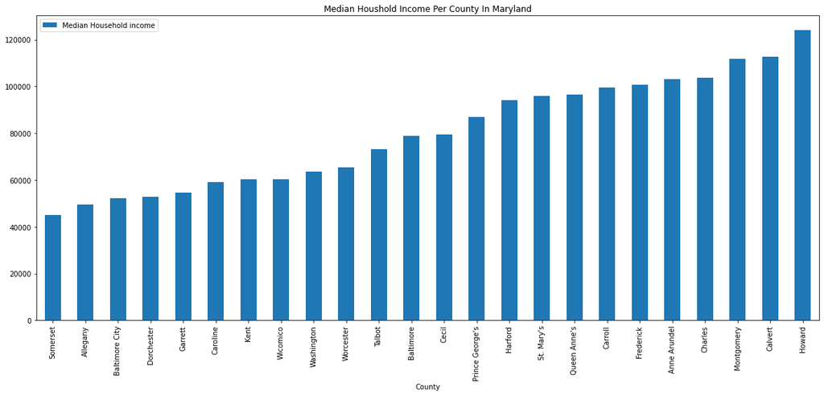

```python
#Replacing string characters
data['Median household income (in 2020 dollars), 2016-2020'] = data['Median household income (in 2020 dollars), 2016-2020'].str.replace(r',|\$','')
data['Median household income (in 2020 dollars), 2016-2020'] = data['Median household income (in 2020 dollars), 2016-2020'].astype(float)

#Getting rid of Maryland and County and paranthesis
data['County'] = data['County'].str.replace(',|Maryland|County|\(|\)','')

#Renaming Columns for easier access
data.rename(columns={"Median household income (in 2020 dollars), 2016-2020":"Median Household income"}, inplace=True)

#Sorting data by income
data = data.sort_values(by=['Median Household income'])

#Plotting the data
data.plot(x="County", y="Median Household income", title="Median Houshold Income Per County In Maryland", kind="bar")
```

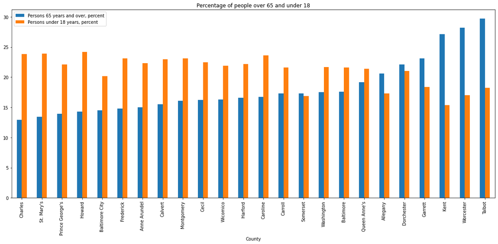

```python
data['Persons 65 years and over, percent'] = data['Persons 65 years and over, percent'].str.replace(r',|\$|\%','')
data['Persons 65 years and over, percent'] = data['Persons 65 years and over, percent'].astype(float)
data['Persons under 18 years, percent'] = data['Persons under 18 years, percent'].str.replace(r'\%','')
data['Persons under 18 years, percent'] = data['Persons under 18 years, percent'].astype(float)
data = data.sort_values(by=['Persons 65 years and over, percent'])
data.plot(x="County",y= [('Persons 65 years and over, percent'),('Persons under 18 years, percent')], title="Percentage of people over 65 and under 18",kind="bar" )
```

Next, we are going to look at the population of each county, specifically the percentage of people over 65 and the percentage of people under 65. For most of the counties it can be seen that if there is a higher percentage of people under 18, there is typically a lower percentage of people 65 and over. The only county with age percentages that are very similar would be Somerset County. In this data, we can also see that there are more counties whose population percentages of people under 65 is less than the counties with a higher population percentage of people over 65. We will be using this data later on to see if there is a difference between the amount of vaccinations between these two population groups.

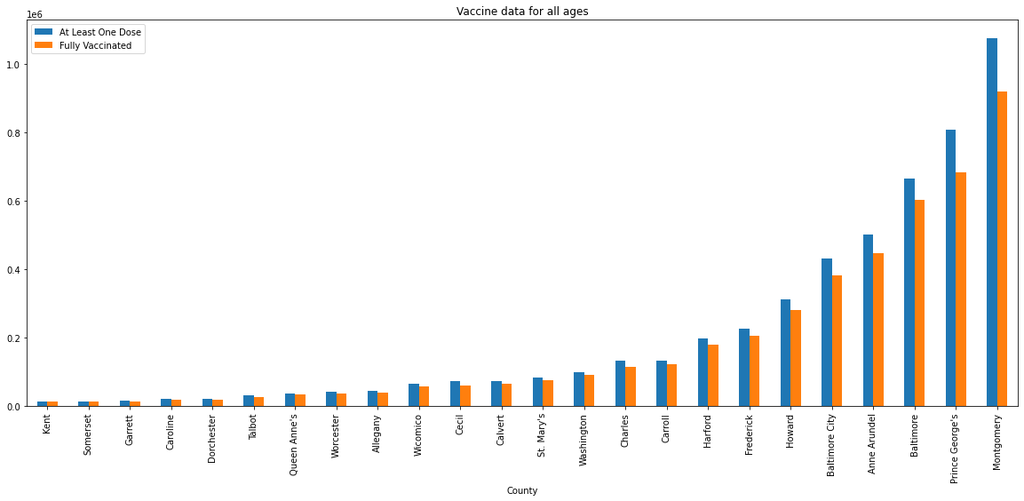

```python
vaccineData['At Least One Dose']=vaccineData['At Least One Dose'].replace(',', '')
vaccineData['At Least One Dose']=vaccineData['At Least One Dose'].astype(int)
vaccineData['Fully Vaccinated']= vaccineData['Fully Vaccinated'].str.replace(',','')
vaccineData['Fully Vaccinated']= vaccineData['Fully Vaccinated'].astype(int)
vaccineData = vaccineData.sort_values(by=['At Least One Dose'])
vaccineData.plot(x="County", y=[('At Least One Dose'), ('Fully Vaccinated')], title="Vaccine data for all ages", kind="bar")
```

```python
temp3 = pd.merge(data, vaccineData, on="County")
vax_pop = temp3[['County','Population Estimates, July 1 2021, (V2021)', 'Fully Vaccinated']]
vax_pop.rename(columns={"Population Estimates, July 1 2021, (V2021)":"Population Estimates"}, inplace=True)
vax_pop['Population Estimates'] = vax_pop['Population Estimates'].str.replace(',','')
vax_pop['Population Estimates'] = vax_pop['Population Estimates'].astype(int)
vax_pop = vax_pop.sort_values(by=['Population Estimates'])
vax_pop.head()
```

|  | County | Population Estimates | Fully Vaccinated |
| --- | --- | --- | --- |
| 21 | Kent | 19270 | 12772 |
| 14 | Somerset | 24584 | 12914 |
| 20 | Garrett | 28702 | 14862 |
| 19 | Dorchester | 32489 | 19042 |
| 12 | Caroline | 33386 | 19147 |

We are now showing the population estimates of each county compared to the fully vaccinated rate. This data will be visualized later on to see the percentage of people vaccinated compared to the total population. It can be seen that Kent County has the lowest population of 19,270 people whereas Montgomery County has the highest population of 1,054,827 people.

```python
age_pop = temp3[['County', 'Population Estimates, July 1 2021, (V2021)', 'Persons 65 years and over, percent']]
age_pop['Persons 65 years and over, percent']= age_pop['Persons 65 years and over, percent'].replace('\%','')
age_pop['Population Estimates, July 1 2021, (V2021)'] = age_pop['Population Estimates, July 1 2021, (V2021)'].str.replace(',','')
age_pop['Persons 65 years and over, percent']= age_pop['Persons 65 years and over, percent'].astype(float)
age_pop['Population Estimates, July 1 2021, (V2021)'] = age_pop['Population Estimates, July 1 2021, (V2021)'].astype(float)
age_pop['Population Under 65'] = age_pop['Population Estimates, July 1 2021, (V2021)']* ((age_pop['Persons 65 years and over, percent'])/100)
age_pop = age_pop.drop(columns=['Persons 65 years and over, percent'])
age_pop.head()
```

|  | County | Population Estimates, July 1 2021, (V2021) | Population Under 65 |
| --- | --- | --- | --- |
| 0 | Charles | 168698.0 | 21762.042 |
| 1 | St. Mary's | 114468.0 | 15338.712 |
| 2 | Prince George's | 955306.0 | 132787.534 |
| 3 | Howard | 334529.0 | 47837.647 |
| 4 | Baltimore City | 576498.0 | 83592.210 |

```python
vaccineAll = pd.merge(vaccineData65, vaccineDataUnder65, on="County")
vaccineAllPop = pd.merge(vax_pop, vaccineAll, on="County")
vaccineAllPop = vaccineAllPop.drop(columns={'Fully Vaccinated'})
vaccineAllPop['Fully Vaccinated 65+'] = vaccineAllPop['Fully Vaccinated 65+'].str.replace(',','')
vaccineAllPop['Fully Vaccinated Under 65'] = vaccineAllPop['Fully Vaccinated Under 65'].str.replace(',','')
vaccineAllPop['Fully Vaccinated 65+']= vaccineAllPop['Fully Vaccinated 65+'].astype(int)
vaccineAllPop['Fully Vaccinated Under 65'] = vaccineAllPop['Fully Vaccinated Under 65'].astype(int)
vaccineAllPop.head()
```

|  | County | Population Estimates | Fully Vaccinated 65+ | Fully Vaccinated Under 65 |
| --- | --- | --- | --- | --- |
| 0 | Kent | 19270 | 4917 | 11970 |
| 1 | Somerset | 24584 | 3671 | 12202 |
| 2 | Garrett | 28702 | 5412 | 14091 |
| 3 | Dorchester | 32489 | 6042 | 17733 |
| 4 | Caroline | 33386 | 5108 | 17495 |

The data above shows the number of people of per county compared to the number of people over 65 who are fully vaccinated and the number of people who are fully vaccinated under 65.

# Data Analysis/Visualization

[figure not shown]

```python
colors = ['#ff9999','#66b3ff']
labels = ['Unvaccinated', 'Vaccinated']
vax_pop[vax_pop.columns[1:]].sum().plot.pie(figsize=(6,6), title = "Percenage of People Vaccinated vs Unvaccinated in Maryland", labels = labels, ylabel= "", shadow=True, autopct='%1.1f%%', explode=[0.03, 0.03], colors=colors)
```

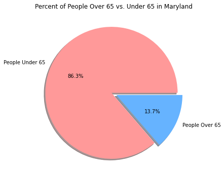

```python
labels=['People Under 65', 'People Over 65']
age_pop[age_pop.columns[1:]].sum().plot.pie(figsize=(6,6), title = "Percent of People Over 65 vs. Under 65 in Maryland", labels = labels, shadow=True, autopct='%1.1f%%', explode=[0.04, 0.04], colors=colors, ylabel = "")
```

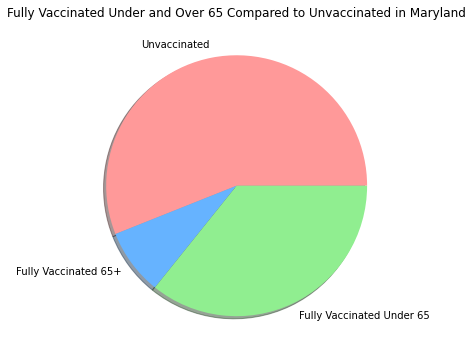

```python
colors = ['#ff9999','#66b3ff', '#90EE90']
labels = ['Unvaccinated', 'Fully Vaccinated 65+', "Fully Vaccinated Under 65"]
vaccineAllPop[vaccineAllPop.columns[1:]].sum().plot.pie(figsize=(6,6), title = "Fully Vaccinated Under and Over 65 Compared to Unvaccinated in Maryland", shadow=True, ylabel = "", labels = labels, colors=colors)
```

Our last pie chart above reveals the ratio between those who are fully vaccinated and unvaccinated, but also reveals how those who are vaccinated are split up between over 65 years of age or under 65 years of age and how they compare to the unvaccinated population. From the graph, we can see that a majority of people vaccinated are under 65 percent.

# Hypothesis Testing

To test our hypothesis, we created a series of scatterplots accompanied by linear regression lines in order to see if there are any trends with the vaccination rates and our independent variables such as age and income. To help do this, we combined our datasets by merging them based on the County names.

```python
temp3 = pd.merge(data, vaccineData, on="County") #Combining our new datasets to a temporary combined dataset so we can access vaccination rates and median income simultaneously
temp3['Fully Vaccinated %'] = temp3['Fully Vaccinated %'].str[:-1] #Removing the percent sign at the end of the data to make it easier to work with
temp3.head()
```

|  | County | Population Estimates, July 1 2021, (V2021) | Population estimates base, April 1, 2020, (V2021) | Population, percent change - April 1, 2020 (estimates base) to July 1, 2021, (V2021) | Population, Census, April 1, 2020 | Population, Census, April 1, 2010 | Persons under 5 years, percent | Persons under 18 years, percent | Persons 65 years and over, percent | Female persons, percent | ... | Nonminority-owned firms, 2012 | Veteran-owned firms, 2012 | Nonveteran-owned firms, 2012 | Population per square mile, 2010 | Land area in square miles, 2010 | FIPS Code | At Least One Dose | At Least One Dose % | Fully Vaccinated | Fully Vaccinated % |
| --- | --- | --- | --- | --- | --- | --- | --- | --- | --- | --- | --- | --- | --- | --- | --- | --- | --- | --- | --- | --- | --- |
| 0 | Charles | 168,698 | 166,617 | 1.20% | 166,617 | 146,551 | 5.90% | 23.8 | 12.9 | 51.80% | ... | 5,464 | 1,487 | 8,861 | 320.2 | 457.75 | "24017" | 131919 | 80.80% | 115372 | 70.70 |
| 1 | St. Mary's | 114,468 | 113,777 | 0.60% | 113,777 | 105,151 | 6.30% | 23.9 | 13.4 | 50.00% | ... | 5,780 | 598 | 6,193 | 294.4 | 357.18 | "24037" | 84824 | 74.70% | 75725 | 66.70 |
| 2 | Prince George's | 955,306 | 967,201 | -1.20% | 967,201 | 863,420 | 6.50% | 22.1 | 13.9 | 51.90% | ... | 16,219 | 7,644 | 67,290 | 1,788.80 | 482.69 | "24033" | 806975 | 88.70% | 683227 | 75.10 |
| 3 | Howard | 334,529 | 332,317 | 0.70% | 332,317 | 287,085 | 5.90% | 24.2 | 14.3 | 51.10% | ... | 18,522 | 2,596 | 26,031 | 1,144.90 | 250.74 | "24027" | 310901 | 95% | 280156 | 86 |
| 4 | Baltimore City | 576,498 | 585,708 | -1.60% | 585,708 | 620,961 | 6.20% | 20.2 | 14.5 | 53.10% | ... | 20,782 | 4,216 | 43,918 | 7,671.50 | 80.94 | "24510" | 432469 | 72.90% | 381900 | 64.30 |

5 rows × 67 columns

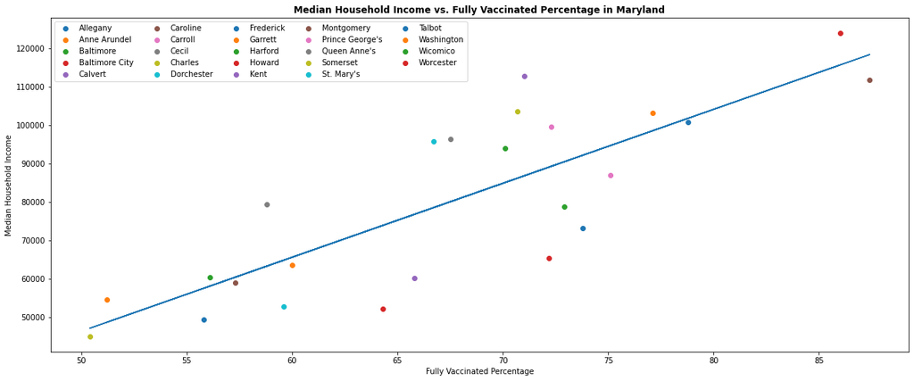

```python
#Setting up and creating Scatterplot
fig, ax = plt.subplots()
plt.rcParams["figure.figsize"] = [20, 8]
for c, county in temp3.groupby('County'):
  ax.scatter(county['Fully Vaccinated %'], county['Median Household income'], label=c)
plt.legend(ncol = 5)
plt.xlabel("Fully Vaccinated Percentage")
plt.ylabel("Median Household Income")
plt.title("Median Household Income vs. Fully Vaccinated Percentage in Maryland", fontweight="bold")
temp3 = temp3.astype({'Fully Vaccinated %':'float'}) #Changing data type from string to float

#Creating linear regression line for Fully Vaccinated vs. Median Household Income
m, b = polyfit(temp3['Fully Vaccinated %'], temp3['Median Household income'], 1)
plt.plot(temp3['Fully Vaccinated %'], (np.multiply(b, temp3['Fully Vaccinated %']) + m))
```

The scatterplot above plots the Median Household Income vs. Fully Vaccinated Percentage. The blue regression line helps reveal the relationship between median income and vaccination rate. Based on the regression line, the higher the median household income the more likely to be fully vaccinated. Based on teh scatterplot, the data appears to be moderate with a positive and linear relationship. These results align with our earlier hypothesis. The reason for this upwards trend could be due to more accessibility to vaccination resources and sites. In addition, the trend could be associated with education levels as we had previously predicted. Since higher income could imply more likelyhood to be able to afford education, individuals might be more aware of vaccination benefits.

In order to continue our hypothesis testing and test the relationship between age and vaccination rates, we will use a new dataset containing vaccination data for persons over 65 years old. We then merged our dataframes in order to create a new one with all the relevant information.

```python
vaccineDataOver65 = pd.read_csv("/content/Vaccine Data 65.csv", sep=',')
temp3 = pd.merge(data, vaccineDataOver65, on="County")
temp3['Fully Vaccinated %'] = temp3['Fully Vaccinated %'].str[:-1] #Removes the percent signs from dataframes
temp3.head()
```

|  | County | Population Estimates, July 1 2021, (V2021) | Population estimates base, April 1, 2020, (V2021) | Population, percent change - April 1, 2020 (estimates base) to July 1, 2021, (V2021) | Population, Census, April 1, 2020 | Population, Census, April 1, 2010 | Persons under 5 years, percent | Persons under 18 years, percent | Persons 65 years and over, percent | Female persons, percent | ... | Nonminority-owned firms, 2012 | Veteran-owned firms, 2012 | Nonveteran-owned firms, 2012 | Population per square mile, 2010 | Land area in square miles, 2010 | FIPS Code | At Least One Dose | At Least One Dose % | Fully Vaccinated | Fully Vaccinated % |
| --- | --- | --- | --- | --- | --- | --- | --- | --- | --- | --- | --- | --- | --- | --- | --- | --- | --- | --- | --- | --- | --- |
| 0 | Charles | 168,698 | 166,617 | 1.20% | 166,617 | 146,551 | 5.90% | 23.8 | 12.9 | 51.80% | ... | 5,464 | 1,487 | 8,861 | 320.2 | 457.75 | "24017" | 22,536 | 95% | 20,460 | 95 |
| 1 | St. Mary's | 114,468 | 113,777 | 0.60% | 113,777 | 105,151 | 6.30% | 23.9 | 13.4 | 50.00% | ... | 5,780 | 598 | 6,193 | 294.4 | 357.18 | "24037" | 15,414 | 95% | 14,083 | 92.70 |
| 2 | Prince George's | 955,306 | 967,201 | -1.20% | 967,201 | 863,420 | 6.50% | 22.1 | 13.9 | 51.90% | ... | 16,219 | 7,644 | 67,290 | 1,788.80 | 482.69 | "24033" | 134,949 | 95% | 119,592 | 94.70 |
| 3 | Howard | 334,529 | 332,317 | 0.70% | 332,317 | 287,085 | 5.90% | 24.2 | 14.3 | 51.10% | ... | 18,522 | 2,596 | 26,031 | 1,144.90 | 250.74 | "24027" | 51,280 | 95% | 47,074 | 95 |
| 4 | Baltimore City | 576,498 | 585,708 | -1.60% | 585,708 | 620,961 | 6.20% | 20.2 | 14.5 | 53.10% | ... | 20,782 | 4,216 | 43,918 | 7,671.50 | 80.94 | "24510" | 75,148 | 87.20% | 69,378 | 80.50 |

5 rows × 67 columns

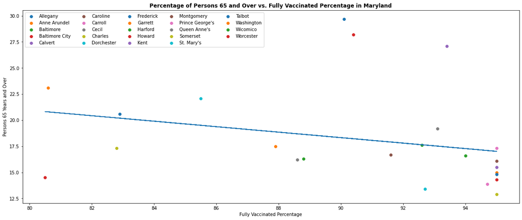

```python
fig, ax = plt.subplots()
plt.rcParams["figure.figsize"] = [20, 8]
for c, county in temp3.groupby('County'):
  ax.scatter(county['Fully Vaccinated %'], county['Persons 65 years and over, percent'], label=c)
plt.legend(ncol = 5)
plt.xlabel("Fully Vaccinated Percentage")
plt.ylabel("Persons 65 Years and Over")
plt.title("Percentage of Persons 65 and Over vs. Fully Vaccinated Percentage in Maryland", fontweight="bold")

temp3 = temp3.astype({'Fully Vaccinated %':'float'})
m, b = polyfit(temp3['Fully Vaccinated %'], temp3['Persons 65 years and over, percent'], 1)
plt.plot(temp3['Fully Vaccinated %'], (np.multiply(b, temp3['Fully Vaccinated %']) + m))
```

The scatterplot above plots the percentage of people 65 years old and older versus their fully vaccinated percentage. The linear regression line shows a slight downward trend, meaning as the percent of 65 year olds decreases, the more likely they are to be vaccinated. In the scatterplot itself, we can see a cluster of points with a very high fully vaccinated percentage, and almost all of them fall near or below the last point of the regression line at around 17.5%. This shows that there is a siginificant amount of counties where when the amount of people 65 and older is low, the more likely they are to be fully vaccinated. The reasoning behind this could be due to the fact that since they are a lower percentage of the population, they might be surrounded by more younger individuals who are likely to give them Covid. However, there are some points that can be seen very far from the regression line at above 25%, but are still fully vaccinated. We believe that the scatterplot is not really conclusive of anything and is not sufficient to support our hypothesis in that the more elderly, the more vaccination rate.

To continue our hypothesis testing, we will now make a scatterplot containing data of persons under 65 years old versus their vaccination rate.

```python
vaccineDataUnder65 = pd.read_csv("/content/Vaccine Data Under 65.csv", sep=',')
#Creating our new dataframe with updated vaccination rates for those between 18 and 65 years old
temp3 = pd.merge(data, vaccineDataUnder65, on="County")
temp3['Fully Vaccinated %'] = temp3['Fully Vaccinated %'].str[:-1]
#Changing the type of our datasets so that we can do arithmetic on them
temp3 = temp3.astype({'Persons 65 years and over, percent':'float'})
temp3 = temp3.astype({'Persons under 18 years, percent':'float'})
#Removing percent sign from column
temp3['Persons under 5 years, percent'] = temp3['Persons under 5 years, percent'].str[:-1]
temp3 = temp3.astype({'Persons under 5 years, percent':'float'})
#Calculating the percent of people between 18 and 65 to align with our dataset
temp3['Persons Between 18 and 65'] = 100 - temp3['Persons 65 years and over, percent'] - temp3['Persons under 18 years, percent'] - temp3['Persons under 5 years, percent']
temp3.head()
```

|  | County | Population Estimates, July 1 2021, (V2021) | Population estimates base, April 1, 2020, (V2021) | Population, percent change - April 1, 2020 (estimates base) to July 1, 2021, (V2021) | Population, Census, April 1, 2020 | Population, Census, April 1, 2010 | Persons under 5 years, percent | Persons under 18 years, percent | Persons 65 years and over, percent | Female persons, percent | ... | Veteran-owned firms, 2012 | Nonveteran-owned firms, 2012 | Population per square mile, 2010 | Land area in square miles, 2010 | FIPS Code | At Least One Dose | At Least One Dose % | Fully Vaccinated | Fully Vaccinated % | Persons Between 18 and 65 |
| --- | --- | --- | --- | --- | --- | --- | --- | --- | --- | --- | --- | --- | --- | --- | --- | --- | --- | --- | --- | --- | --- |
| 0 | Charles | 168,698 | 166,617 | 1.20% | 166,617 | 146,551 | 5.9 | 23.8 | 12.9 | 51.80% | ... | 1,487 | 8,861 | 320.2 | 457.75 | "24017" | 114,915 | 92% | 100,534 | 81 | 57.4 |
| 1 | St. Mary's | 114,468 | 113,777 | 0.60% | 113,777 | 105,151 | 6.3 | 23.9 | 13.4 | 50.00% | ... | 598 | 6,193 | 294.4 | 357.18 | "24037" | 75,125 | 87% | 66,989 | 77.50 | 56.4 |
| 2 | Prince George's | 955,306 | 967,201 | -1.20% | 967,201 | 863,420 | 6.5 | 22.1 | 13.9 | 51.90% | ... | 7,644 | 67,290 | 1,788.80 | 482.69 | "24033" | 707,078 | 95% | 598,981 | 84.60 | 57.5 |
| 3 | Howard | 334,529 | 332,317 | 0.70% | 332,317 | 287,085 | 5.9 | 24.2 | 14.3 | 51.10% | ... | 2,596 | 26,031 | 1,144.90 | 250.74 | "24027" | 259,468 | 95% | 232,812 | 94 | 55.6 |
| 4 | Baltimore City | 576,498 | 585,708 | -1.60% | 585,708 | 620,961 | 6.2 | 20.2 | 14.5 | 53.10% | ... | 4,216 | 43,918 | 7,671.50 | 80.94 | "24510" | 393,176 | 83.00% | 348,652 | 73.60 | 59.1 |

5 rows × 68 columns

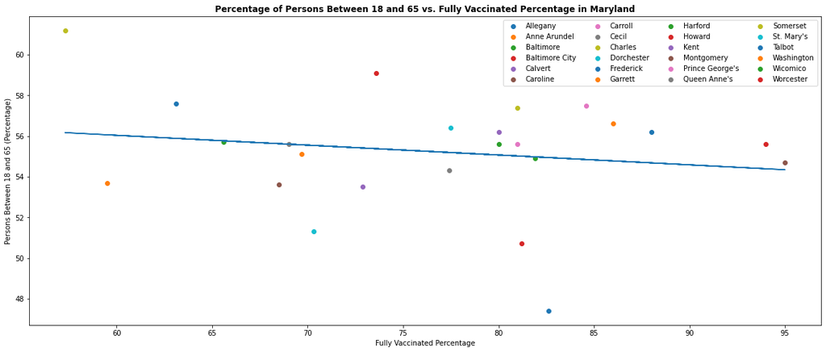

```python
fig, ax = plt.subplots()
plt.rcParams["figure.figsize"] = [20, 8]
for c, county in temp3.groupby('County'):
  ax.scatter(county['Fully Vaccinated %'], county['Persons Between 18 and 65'], label=c)
plt.legend(ncol = 4)
plt.xlabel("Fully Vaccinated Percentage")
plt.ylabel("Persons Between 18 and 65 (Percentage)")
plt.title("Percentage of Persons Between 18 and 65 vs. Fully Vaccinated Percentage in Maryland", fontweight="bold")

temp3 = temp3.astype({'Fully Vaccinated %':'float'})
m, b = polyfit(temp3['Fully Vaccinated %'], temp3['Persons Between 18 and 65'], 1)
plt.plot(temp3['Fully Vaccinated %'], (np.multiply(b, temp3['Fully Vaccinated %']) + m))
```

The last scatterplot above plots the relationship between the percent population between 18 and 65 versus their fully vaccinated percentage. The linear regression line looks very similar to the previous scatterplot regression line, as it has a slight downward trend. However, the linear regression line does not appear indicative of anything conclusive as the points on the scatterplot appear to be very evenly distributed. The spread of the graph appears to be very weak with no relationship.

# Conclusion

Based on our scatterplots above, the distribution of vaccines would be more efficient and less wasteful if we prioritized giving areas with higher median income as they appear to be more likely to use them. However, it is important to note that there may be other reasons as to why the vaccination rate of higher income families is high. For example, these families might have more accesibility to vaccines since higher income means they reside in an area with better living conditions.

In regards to the influence of the percent of persons 65 years and older versus the vaccination rate, the data provided and the linear regression line is not significant enough to show a trend or conclusive results. This might be because the age is not an indicator of vaccination rates as we predicted in our hypothesis. We found similar non-conclusive results when analyzing the influence of the percent of persons under 65 years versus vaccination rate, as the linear regression and scatterplots did not appear sufficient and have a strong linear spread. The similarities between these two scatterplots and regression linears adds reassurance towards the lack of influence that the percent age of the population has on vaccination rate.

Overall, there are many other factors that could influence vaccination rate such as race, behavior, or political affiliation. Based on our results, we could save resources by distributing to high income families regardless of age. If we were to do this project again, we would include more counties and a larger dataset to get more conclusive results.

CSVs used can be found here: https://github.com/MattRelacion/320CovidCSV